# Solutions for week11

Author

Jarkko Toivonen

Published

August 30, 2026

```r
library(tibble)
library(purrr)
library(dplyr)
library(stringr)
library(ggcyto)
library(flowGate)
library(flowWorkspace)
library(magrittr)
library(openCyto)
library(tidyr)
library(fBasics)    # For dagotest
library(broom)

source("original_functions.R")

data_path <- file.path("data")
result_path <- file.path("results")
```

# Problem 1

> Implement additional openCyto gates, and validate that they are being placed correctly using Utility_GatingPlot(). Update the gate_range arguments until satisfied. Then, add new gates, and run the resulting dataset through CombinedFlow(), screenshotting any values that return with p-values that upon visualizing the data also look reasonable (not driven by a single-outlier).

```r
# remotes::install_github("DavidRach/Luciernaga")
library(Luciernaga)
```

```r
StorageLocation <- file.path("data") # For Quarto Rendering
# StorageLocation <- file.path("course", "11_DataForStats", "data")

OutputFolder <- file.path("data") # For Quarto Rendering
# OutputFolder <- file.path("course", "11_DataForStats", "outputs")

fcs_files <- list.files(StorageLocation, pattern=".fcs", full.names=TRUE)

SFC_cytoset <- load_cytoset_from_fcs(fcs_files, truncate_max_range=FALSE, transformation=FALSE)
SFC_GatingSet <- GatingSet(SFC_cytoset)
SFC_GatingSet
```

```
A GatingSet with 19 samples
```

```r
SFC_Parameters <- colnames(SFC_GatingSet)
FluorophoresOnly <- SFC_Parameters[!stringr::str_detect(SFC_Parameters, "FSC|SSC|Time")]

Biexponential <- flowjo_biexp_trans(channelRange=4096, maxValue=262144,
     pos=4.5, neg=2, widthBasis=-750)
MyBiexTransform <- transformerList(FluorophoresOnly, Biexponential)
transform(SFC_GatingSet, MyBiexTransform)
```

```
A GatingSet with 19 samples
```

```r
CurrentMetadata <- pData(SFC_GatingSet)
CurrentMetadata <- CurrentMetadata |> mutate(specimen = name) |>
     mutate(specimen = stringr::str_extract(specimen, "INF\\d+")) |>
     mutate(specimen = stringr::str_replace(specimen, "INF0(\\d{3})", "INF\\1"))

TheCSV <- list.files(StorageLocation, pattern="Metadata.csv", full.names=TRUE)
AdditionalMetadata <- read.csv(TheCSV, check.names=FALSE)
AdditionalMetadata <- AdditionalMetadata|>
     mutate(specimen = stringr::str_replace(specimen, "INF0(\\d{3})", "INF\\1"))
```

```r
UpdatedMetadata <- left_join(CurrentMetadata, AdditionalMetadata, by="specimen")
rownames(UpdatedMetadata) <- UpdatedMetadata$name
pData(SFC_GatingSet) <- UpdatedMetadata
pData(SFC_GatingSet)
```

|  | name | specimen | Condition | ptype | timepoint | infant_sex |
| --- | --- | --- | --- | --- | --- | --- |
| 2025_07_29_AB_03_INF134_00_SEB__Tcells.fcs | 2025_07_29_AB_03_INF134_00_SEB__Tcells.fcs | INF134 | SEB | HEU-lo | 0 | Female |
| 2025_07_29_AB_03_INF148_00_SEB__Tcells.fcs | 2025_07_29_AB_03_INF148_00_SEB__Tcells.fcs | INF148 | SEB | HU | 0 | Female |
| 2025_07_29_AB_03_INF191_00_SEB__Tcells.fcs | 2025_07_29_AB_03_INF191_00_SEB__Tcells.fcs | INF191 | SEB | HEU-hi | 0 | Female |
| 2025_07_31_AB_04_INF124_00_SEB__Tcells.fcs | 2025_07_31_AB_04_INF124_00_SEB__Tcells.fcs | INF124 | SEB | HEU-hi | 0 | Male |
| 2025_07_31_AB_04_INF149_00_SEB__Tcells.fcs | 2025_07_31_AB_04_INF149_00_SEB__Tcells.fcs | INF149 | SEB | HU | 0 | Female |
| 2025_07_31_AB_04_INF169_00_SEB__Tcells.fcs | 2025_07_31_AB_04_INF169_00_SEB__Tcells.fcs | INF169 | SEB | HEU-lo | 0 | Female |
| 2025_08_05_AB_05_INF019_00_SEB__Tcells.fcs | 2025_08_05_AB_05_INF019_00_SEB__Tcells.fcs | INF019 | SEB | HEU-lo | 0 | Female |
| 2025_08_05_AB_05_INF032_00_SEB__Tcells.fcs | 2025_08_05_AB_05_INF032_00_SEB__Tcells.fcs | INF032 | SEB | HU | 0 | Female |
| 2025_08_05_AB_05_INF180_00_SEB__Tcells.fcs | 2025_08_05_AB_05_INF180_00_SEB__Tcells.fcs | INF180 | SEB | HEU-hi | 0 | Male |
| 2025_08_07_AB_06_INF155_00_SEB__Tcells.fcs | 2025_08_07_AB_06_INF155_00_SEB__Tcells.fcs | INF155 | SEB | HEU-lo | 0 | Female |
| 2025_08_07_AB_06_INF158_00_SEB__Tcells.fcs | 2025_08_07_AB_06_INF158_00_SEB__Tcells.fcs | INF158 | SEB | HU | 0 | Male |
| 2025_08_07_AB_06_INF159_00_SEB__Tcells.fcs | 2025_08_07_AB_06_INF159_00_SEB__Tcells.fcs | INF159 | SEB | HEU-hi | 0 | Male |
| 2025_08_22_AB_07_INF023_00_SEB__Tcells.fcs | 2025_08_22_AB_07_INF023_00_SEB__Tcells.fcs | INF023 | SEB | HEU-hi | 0 | Female |
| 2025_08_22_AB_07_INF030_00_SEB__Tcells.fcs | 2025_08_22_AB_07_INF030_00_SEB__Tcells.fcs | INF030 | SEB | HU | 0 | Male |
| 2025_08_28_AB_08_INF166_00_SEB__Tcells.fcs | 2025_08_28_AB_08_INF166_00_SEB__Tcells.fcs | INF166 | SEB | HU | 0 | Female |
| 2025_08_28_AB_08_INF199_00_SEB__Tcells.fcs | 2025_08_28_AB_08_INF199_00_SEB__Tcells.fcs | INF199 | SEB | HEU-hi | 0 | Male |
| 2025_08_28_AB_08_INF207_00_SEB__Tcells.fcs | 2025_08_28_AB_08_INF207_00_SEB__Tcells.fcs | INF207 | SEB | HEU-lo | 0 | Male |
| 2025_08_30_AB_09_INF614_00_SEB__Tcells.fcs | 2025_08_30_AB_09_INF614_00_SEB__Tcells.fcs | INF614 | SEB | HU | 0 | Female |
| 2025_08_30_AB_09_INF622_00_SEB__Tcells.fcs | 2025_08_30_AB_09_INF622_00_SEB__Tcells.fcs | INF622 | SEB | HEU-lo | 0 | Male |

```r
OurGateTemplate <- list.files(StorageLocation, pattern="GatesUnmixed.csv", full.names=TRUE)
Example <- read.csv(OurGateTemplate, check.names=FALSE)
Example
```

| alias | pop | parent | dims | gating_method | gating_args | collapseDataForGating | groupBy | preprocessing_method | preprocessing_args |
| --- | --- | --- | --- | --- | --- | --- | --- | --- | --- |
| singlets | + | root | FSC-A,FSC-H | singletGate |  | FALSE | NA | NA | NA |
| lymphocytes | + | singlets | FSC-A, SSC-A | flowClust | K=2, target=c(2e6, 5e5) | FALSE | NA | NA | NA |
| Tcells | + | lymphocytes | Spark Blue 550-A | gate_mindensity |  | FALSE | NA | NA | NA |
| * | +/- | Tcells | Vd2 | gate_mindensity | gate_range=c(2500,2750) | FALSE | NA | NA | NA |
| * | +/- | Vd2- | CD4 | gate_mindensity | gate_range=c(2500,2750) | FALSE | NA | NA | NA |
| * | +/- | CD4- | CD8 | gate_mindensity |  | FALSE | NA | NA | NA |
| Vd2_IFNg | + | Vd2+ | IFNg | gate_mindensity | gate_range=c(2900,3000) | FALSE | NA | NA | NA |
| Vd2_TNFa | + | Vd2+ | TNFa | gate_mindensity | gate_range=c(2900,3000) | FALSE | NA | NA | NA |
| Vd2_IL2 | + | Vd2+ | IL-2 | gate_mindensity | gate_range=c(2900,3000) | FALSE | NA | NA | NA |
| Vd2_CD107a | + | Vd2+ | CD107a | gate_mindensity | gate_range=c(2900,3000) | FALSE | NA | NA | NA |
| CD4_IFNg | + | CD4+ | IFNg | gate_mindensity | gate_range=c(2900,3000) | FALSE | NA | NA | NA |
| CD4_TNFa | + | CD4+ | TNFa | gate_mindensity | gate_range=c(2900,3000) | FALSE | NA | NA | NA |
| CD4_IL2 | + | CD4+ | IL-2 | gate_mindensity | gate_range=c(2900,3000) | FALSE | NA | NA | NA |
| CD4_CD107a | + | CD4+ | CD107a | gate_mindensity | gate_range=c(2900,3000) | FALSE | NA | NA | NA |
| CD8_IFNg | + | CD8+ | IFNg | gate_mindensity | gate_range=c(2900,3000) | FALSE | NA | NA | NA |
| CD8_TNFa | + | CD8+ | TNFa | gate_mindensity | gate_range=c(2900,3000) | FALSE | NA | NA | NA |
| CD8_IL2 | + | CD8+ | IL-2 | gate_mindensity | gate_range=c(2900,3000) | FALSE | NA | NA | NA |
| CD8_CD107a | + | CD8+ | CD107a | gate_mindensity | gate_range=c(2900,3000) | FALSE | NA | NA | NA |
| DN_IFNg | + | CD8- | IFNg | gate_mindensity | gate_range=c(2900,3000) | FALSE | NA | NA | NA |
| DN_TNFa | + | CD8- | TNFa | gate_mindensity | gate_range=c(2900,3000) | FALSE | NA | NA | NA |
| DN_IL2 | + | CD8- | IL-2 | gate_mindensity | gate_range=c(2900,3000) | FALSE | NA | NA | NA |
| DN_CD107a | + | CD8- | CD107a | gate_mindensity | gate_range=c(2900,3000) | FALSE | NA | NA | NA |

pop = +/- means create both populations. Alias then has to be an asterisk.

https://www.bioconductor.org/packages//release/bioc/vignettes/openCyto/inst/doc/HowToWriteCSVTemplate.html

What markers we have available?

```r
markernames(SFC_cytoset[[1]]) %>% unname()
```

```
 [1] "CD62L"     "CD69"      "CCR4"      "Vd2"       "CD38"      "CD4"
 [7] "Dump"      "CD161"     "CD16"      "CD45RA"    "CD8"       "Va7.2"
[13] "IFNg"      "CCR6"      "FoxP3"     "CD3"       "CD45"      "PD1"
[19] "CD26"      "CXCR5"     "ICOS"      "TNFa"      "CXCR3"     "CD127"
[25] "CD25"      "HLA-DR"    "CD39"      "IL-2"      "CD107a"    "Viability"
[31] "CD27"      "CCR7"
```

```r
# install.packages("data.table") # CRAN
GatesToApply <- data.table::fread(OurGateTemplate)
```

Add one more gate to the dataframe.

```r
row <- data.frame(alias="Tcells_CD27", pop="+", parent = "Tcells", dims="CD27", gating_method="gate_mindensity",
  gating_args="gate_range=c(2900,3000)", collapseDataForGating=FALSE)
GatesToApply <- GatesToApply %>% bind_rows(row)
TheFullTemplate <- gatingTemplate(GatesToApply)
```

```
expanding pop: +/- to Vd2+/Vd2-
```

```
expanding pop: +/- to CD4+/CD4-
```

```
expanding pop: +/- to CD8+/CD8-
```

```
Adding population:singlets
```

```
Adding population:lymphocytes
```

```
Adding population:Tcells
```

```
Adding population:Vd2+
```

```
Adding population:Vd2-
```

```
Adding population:CD4+
```

```
Adding population:CD4-
```

```
Adding population:CD8+
```

```
Adding population:CD8-
```

```
Adding population:Vd2_IFNg
```

```
Adding population:Vd2_TNFa
```

```
Adding population:Vd2_IL2
```

```
Adding population:Vd2_CD107a
```

```
Adding population:CD4_IFNg
```

```
Adding population:CD4_TNFa
```

```
Adding population:CD4_IL2
```

```
Adding population:CD4_CD107a
```

```
Adding population:CD8_IFNg
```

```
Adding population:CD8_TNFa
```

```
Adding population:CD8_IL2
```

```
Adding population:CD8_CD107a
```

```
Adding population:DN_IFNg
```

```
Adding population:DN_TNFa
```

```
Adding population:DN_IL2
```

```
Adding population:DN_CD107a
```

```
Adding population:Tcells_CD27
```

Do the gating.

```r
gt_gating(TheFullTemplate, SFC_GatingSet)
```

```
Gating for 'singlets'
```

```
done!
```

```
done.
```

```
Gating for 'lymphocytes'
```

[output not shown]

[output not shown]

[output not shown]

[output not shown]

[output not shown]

[output not shown]

[output not shown]

[output not shown]

[output not shown]

[output not shown]

[output not shown]

[output not shown]

[output not shown]

[output not shown]

[output not shown]

[output not shown]

[output not shown]

[output not shown]

[output not shown]

[output not shown]

[output not shown]

[output not shown]

[output not shown]

[output not shown]

[output not shown]

[output not shown]

[output not shown]

[output not shown]

[output not shown]

[output not shown]

[output not shown]

[output not shown]

[output not shown]

[output not shown]

[output not shown]

[output not shown]

[output not shown]

[output not shown]

```
done!
```

```
done.
```

```
Gating for 'Tcells'
```

```
done!
```

```
done.
```

```
Gating for 'Tcells_CD27'
```

```
done!
```

```
done.
```

```
Gating for 'Vd2+'
```

```
done!
```

```
done.
```

```
Gating for 'Vd2_CD107a'
```

```
done!
```

```
done.
```

```
Gating for 'Vd2_IL2'
```

```
done!
```

```
done.
```

```
Gating for 'Vd2_TNFa'
```

```
done!
```

```
done.
```

```
Gating for 'Vd2_IFNg'
```

```
done!
```

```
done.
```

```
Population 'Vd2-'
```

```
done!
```

```
done.
```

```
Gating for 'CD4+'
```

```
done!
```

```
done.
```

```
Gating for 'CD4_CD107a'
```

```
done!
```

```
done.
```

```
Gating for 'CD4_IL2'
```

```
done!
```

```
done.
```

```
Gating for 'CD4_TNFa'
```

```
done!
```

```
done.
```

```
Gating for 'CD4_IFNg'
```

```
done!
```

```
done.
```

```
Population 'CD4-'
```

```
done!
```

```
done.
```

```
Gating for 'CD8+'
```

```
done!
```

```
done.
```

```
Gating for 'CD8_CD107a'
```

```
done!
```

```
done.
```

```
Gating for 'CD8_IL2'
```

```
done!
```

```
done.
```

```
Gating for 'CD8_TNFa'
```

```
done!
```

```
done.
```

```
Gating for 'CD8_IFNg'
```

```
done!
```

```
done.
```

```
Population 'CD8-'
```

```
done!
```

```
done.
```

```
Gating for 'DN_CD107a'
```

```
done!
```

```
done.
```

```
Gating for 'DN_IL2'
```

```
done!
```

```
done.
```

```
Gating for 'DN_TNFa'
```

```
done!
```

```
done.
```

```
Gating for 'DN_IFNg'
```

```
done!
```

```
done.
```

```
finished.
```

Check the plots.

```
$`1`
```

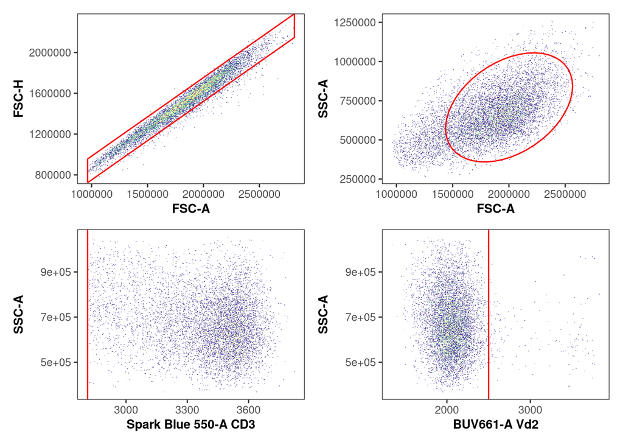

```
$`2`
```

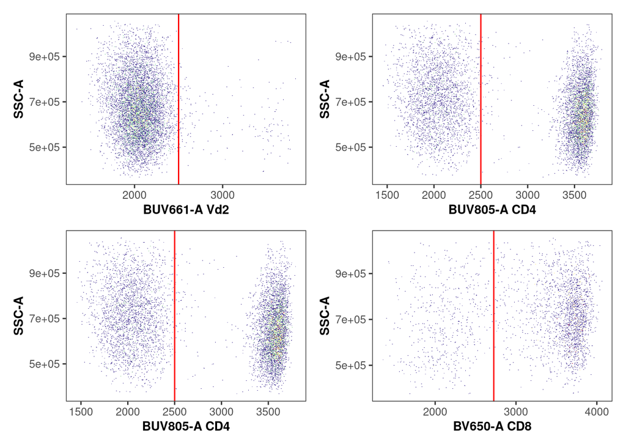

```
$`3`
```

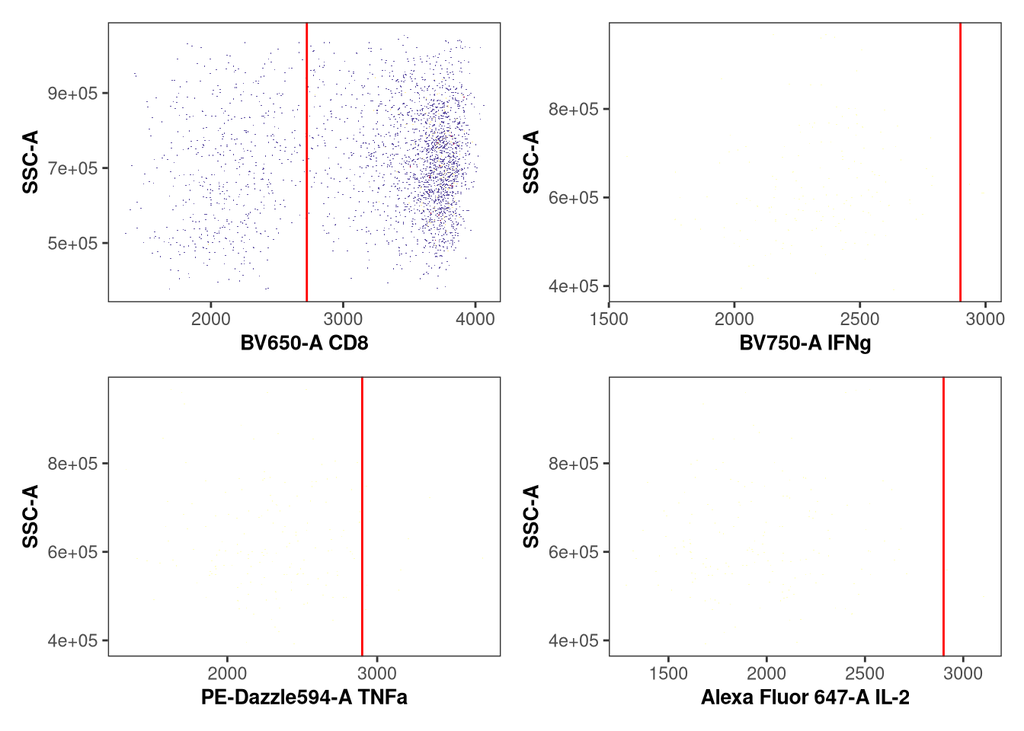

```
$`4`
```

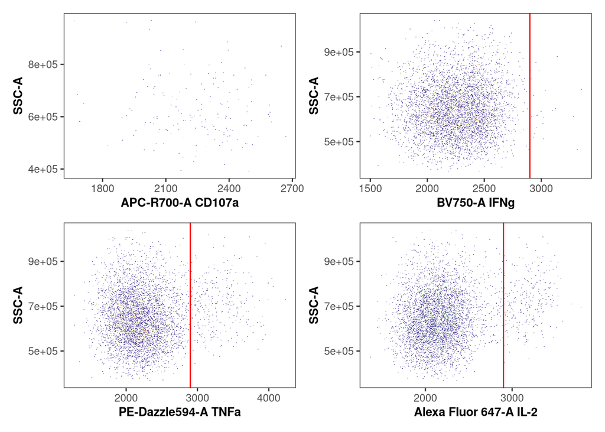

```
$`5`
```

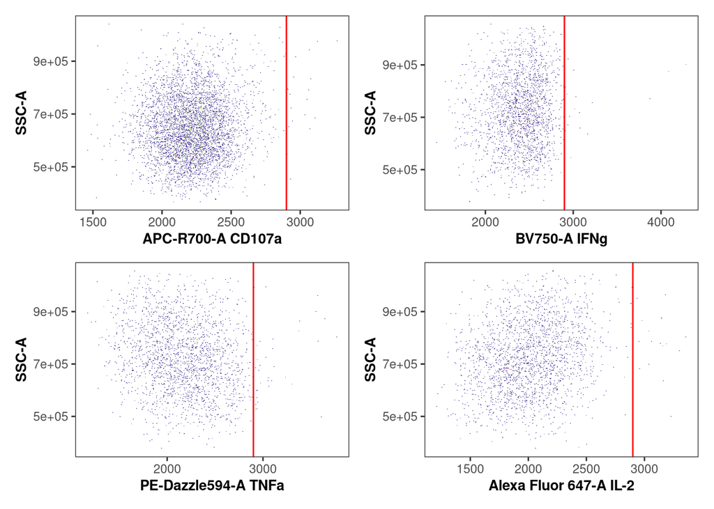

```
$`6`
```

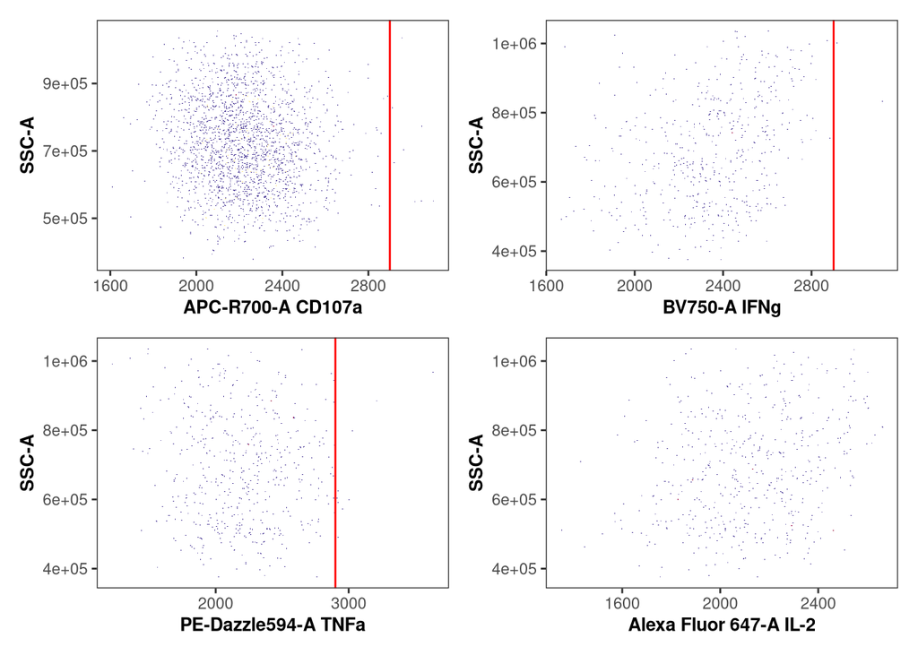

```
$`7`
```

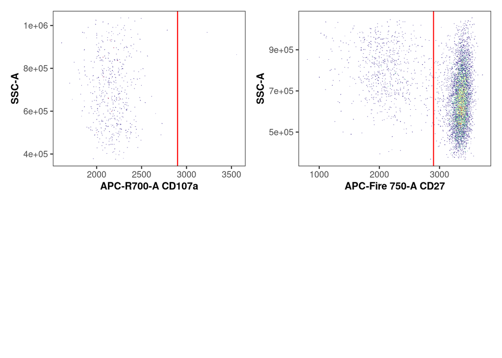

```r
IndividualPlot <- Luciernaga::Utility_GatingPlots(x=SFC_GatingSet[[1]],
 sample.name = "GUID", removestrings = ".fcs", gtFile = GatesToApply, returnType="patchwork")
IndividualPlot
```

Looks great.

Add one more gate, now using a different method.

```r
gs_add_gating_method(SFC_GatingSet,
                     pop="+",
                     parent = "Tcells",
                     dims = "CCR7",
                     alias = "Tcells_CCR7",
                     gating_method = "gate_mindensity",
                     gating_args = "gate_range=c(2900, 3000)")
```

```
...
```

```
done
```

```r
Data <- gs_pop_get_count_with_meta(SFC_GatingSet, "freq")
```

```
Processing sample names..
```

```
merging..
```

```
Done
```

```r
Data %>% head()
```

| name | Population | Parent | Frequency | ParentFrequency | sampleName | specimen | Condition | ptype | timepoint | infant_sex |
| --- | --- | --- | --- | --- | --- | --- | --- | --- | --- | --- |
| 2025_07_29_AB_03_INF134_00_SEB__Tcells.fcs | /singlets | root | 0.9633 | 1.0000 | 2025_07_29_AB_03_INF134_00_SEB__Tcells.fcs | INF134 | SEB | HEU-lo | 0 | Female |
| 2025_07_29_AB_03_INF134_00_SEB__Tcells.fcs | /singlets/lymphocytes | /singlets | 0.7774 | 0.9633 | 2025_07_29_AB_03_INF134_00_SEB__Tcells.fcs | INF134 | SEB | HEU-lo | 0 | Female |
| 2025_07_29_AB_03_INF134_00_SEB__Tcells.fcs | /singlets/lymphocytes/Tcells | /singlets/lymphocytes | 0.7774 | 0.7774 | 2025_07_29_AB_03_INF134_00_SEB__Tcells.fcs | INF134 | SEB | HEU-lo | 0 | Female |
| 2025_07_29_AB_03_INF134_00_SEB__Tcells.fcs | /singlets/lymphocytes/Tcells/Tcells_CD27 | /singlets/lymphocytes/Tcells | 0.7072 | 0.7774 | 2025_07_29_AB_03_INF134_00_SEB__Tcells.fcs | INF134 | SEB | HEU-lo | 0 | Female |
| 2025_07_29_AB_03_INF134_00_SEB__Tcells.fcs | /singlets/lymphocytes/Tcells/Vd2+ | /singlets/lymphocytes/Tcells | 0.0165 | 0.7774 | 2025_07_29_AB_03_INF134_00_SEB__Tcells.fcs | INF134 | SEB | HEU-lo | 0 | Female |
| 2025_07_29_AB_03_INF134_00_SEB__Tcells.fcs | /singlets/lymphocytes/Tcells/Vd2+/Vd2_CD107a | /singlets/lymphocytes/Tcells/Vd2+ | 0.0000 | 0.0165 | 2025_07_29_AB_03_INF134_00_SEB__Tcells.fcs | INF134 | SEB | HEU-lo | 0 | Female |

```r
# colnames(Data)
Data$Population <- basename(Data$Population)
Data$Frequency <- round(Data$Frequency, 2)

RemoveTheseColumns <- c("Parent", "ParentFrequency", "name", "sampleName")

Data <- Data |> select(!tidyselect::any_of(RemoveTheseColumns))
Data <- Data |> relocate(specimen, Condition, timepoint, ptype, infant_sex, .before=Population)
```

```r
Data <- Data |> pivot_wider(names_from=Population, values_from = Frequency)
```

```r
shape_sex <- c("Female" = 22, "Male" = 21)
shape_ptype <- c("HU" = 22, "HEU-lo" = 21, "HEU-hi" = 21)

fill_sex <- c("Female" = "white", "Male" = "black")
fill_ptype <- c("HU" = "white", "HEU-lo" = "darkgray", "HEU-hi" = "black")
```

Try with the newly added gate.

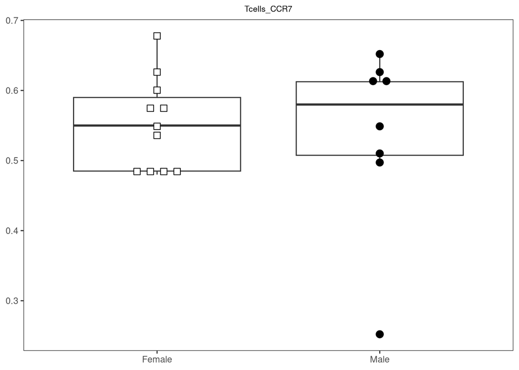

```r
CombinedFlow(data=Data, theColumn="Tcells_CCR7", theFactor="infant_sex",
     shape_palette=shape_sex, fill_palette=fill_sex, parametric = "parametric")
```

Not significant.

Let’s check all gates.

```r
TheColumns <- colnames(Data[6:ncol(Data)])
plots <- purrr::map(TheColumns, ~ CombinedFlow(theColumn = .x, data=Data, theFactor="infant_sex",
     shape_palette=shape_sex, fill_palette=fill_sex, parametric = "parametric"))
```

Create pdfs.

```r
PDF <- Utility_Patchwork(x=plots, thecolumns=2, therows=3,
     returntype="pdf", outfolder=result_path, filename="AllThePlots")
```

```
$`1`
```

```
$`2`
```

```
$`3`
```

```
$`4`
```

```
$`5`
```

CD4_IFNg population seems to be significant difference between sexes that is not driven by a single outlier

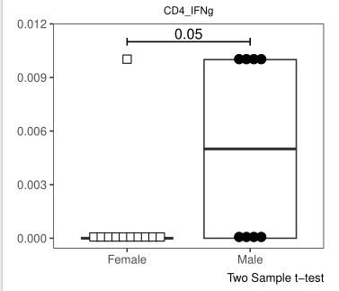

# Problem 2

> In our ggbeeswarm boxplot, currently we are seeing the proportion on the y-axis. Figure out how to modify the StatPlotsForFlow() function to instead display the axis as a percentage, and then using additional function arguments and conditions, set the function up to allow you to switch between as desired. Also, externalize size and cex to modify your beeswarm boxplots in an easier fashion!

```r
Data
```

| specimen | Condition | timepoint | ptype | infant_sex | singlets | lymphocytes | Tcells | Tcells_CD27 | Vd2+ | Vd2_CD107a | Vd2_IL2 | Vd2_TNFa | Vd2_IFNg | Vd2- | CD4+ | CD4_CD107a | CD4_IL2 | CD4_TNFa | CD4_IFNg | CD4- | CD8+ | CD8_CD107a | CD8_IL2 | CD8_TNFa | CD8_IFNg | CD8- | DN_CD107a | DN_IL2 | DN_TNFa | … |
| --- | --- | --- | --- | --- | --- | --- | --- | --- | --- | --- | --- | --- | --- | --- | --- | --- | --- | --- | --- | --- | --- | --- | --- | --- | --- | --- | --- | --- | --- | --- |
| INF134 | SEB | 0 | HEU-lo | Female | 0.96 | 0.78 | 0.78 | 0.71 | 0.02 | 0 | 0 | 0 | 0 | 0.76 | 0.50 | 0.00 | 0.03 | 0.03 | 0.00 | 0.26 | 0.21 | 0.00 | 0.00 | 0.00 | 0.00 | 0.05 | 0 | 0 | 0 | … |
| INF148 | SEB | 0 | HU | Female | 0.97 | 0.76 | 0.76 | 0.74 | 0.01 | 0 | 0 | 0 | 0 | 0.75 | 0.53 | 0.00 | 0.01 | 0.02 | 0.00 | 0.22 | 0.18 | 0.00 | 0.00 | 0.00 | 0.00 | 0.04 | 0 | 0 | 0 | … |
| INF191 | SEB | 0 | HEU-hi | Female | 0.96 | 0.77 | 0.77 | 0.73 | 0.04 | 0 | 0 | 0 | 0 | 0.74 | 0.38 | 0.00 | 0.00 | 0.00 | 0.00 | 0.35 | 0.28 | 0.00 | 0.00 | 0.00 | 0.00 | 0.08 | 0 | 0 | 0 | … |
| INF124 | SEB | 0 | HEU-hi | Male | 0.96 | 0.80 | 0.80 | 0.77 | 0.03 | 0 | 0 | 0 | 0 | 0.77 | 0.55 | 0.00 | 0.04 | 0.03 | 0.00 | 0.22 | 0.18 | 0.00 | 0.00 | 0.00 | 0.00 | 0.04 | 0 | 0 | 0 | … |
| INF149 | SEB | 0 | HU | Female | 0.96 | 0.81 | 0.81 | 0.74 | 0.03 | 0 | 0 | 0 | 0 | 0.77 | 0.47 | 0.00 | 0.04 | 0.02 | 0.00 | 0.30 | 0.26 | 0.00 | 0.00 | 0.00 | 0.00 | 0.04 | 0 | 0 | 0 | … |
| INF169 | SEB | 0 | HEU-lo | Female | 0.96 | 0.74 | 0.74 | 0.72 | 0.02 | 0 | 0 | 0 | 0 | 0.73 | 0.56 | 0.00 | 0.01 | 0.02 | 0.00 | 0.16 | 0.09 | 0.00 | 0.00 | 0.00 | 0.00 | 0.07 | 0 | 0 | 0 | … |
| INF019 | SEB | 0 | HEU-lo | Female | 0.97 | 0.77 | 0.77 | 0.74 | 0.03 | 0 | 0 | 0 | 0 | 0.75 | 0.56 | 0.01 | 0.07 | 0.07 | 0.00 | 0.19 | 0.17 | 0.00 | 0.00 | 0.00 | 0.00 | 0.03 | 0 | 0 | 0 | … |
| INF032 | SEB | 0 | HU | Female | 0.97 | 0.77 | 0.77 | 0.75 | 0.02 | 0 | 0 | 0 | 0 | 0.75 | 0.55 | 0.00 | 0.04 | 0.05 | 0.00 | 0.20 | 0.18 | 0.00 | 0.00 | 0.00 | 0.00 | 0.02 | 0 | 0 | 0 | … |
| INF180 | SEB | 0 | HEU-hi | Male | 0.97 | 0.79 | 0.79 | 0.74 | 0.02 | 0 | 0 | 0 | 0 | 0.77 | 0.51 | 0.00 | 0.07 | 0.08 | 0.00 | 0.27 | 0.23 | 0.00 | 0.00 | 0.00 | 0.00 | 0.03 | 0 | 0 | 0 | … |
| INF155 | SEB | 0 | HEU-lo | Female | 0.96 | 0.80 | 0.80 | 0.78 | 0.01 | 0 | 0 | 0 | 0 | 0.78 | 0.56 | 0.00 | 0.01 | 0.01 | 0.00 | 0.22 | 0.17 | 0.00 | 0.00 | 0.00 | 0.00 | 0.05 | 0 | 0 | 0 | … |
| INF158 | SEB | 0 | HU | Male | 0.95 | 0.73 | 0.73 | 0.71 | 0.02 | 0 | 0 | 0 | 0 | 0.71 | 0.46 | 0.00 | 0.03 | 0.03 | 0.01 | 0.26 | 0.24 | 0.00 | 0.00 | 0.00 | 0.00 | 0.02 | 0 | 0 | 0 | … |
| INF159 | SEB | 0 | HEU-hi | Male | 0.96 | 0.75 | 0.75 | 0.74 | 0.03 | 0 | 0 | 0 | 0 | 0.72 | 0.55 | 0.00 | 0.02 | 0.03 | 0.01 | 0.17 | 0.15 | 0.00 | 0.00 | 0.00 | 0.00 | 0.02 | 0 | 0 | 0 | … |
| INF023 | SEB | 0 | HEU-hi | Female | 0.97 | 0.80 | 0.80 | 0.70 | 0.02 | 0 | 0 | 0 | 0 | 0.78 | 0.54 | 0.00 | 0.09 | 0.06 | 0.01 | 0.24 | 0.18 | 0.00 | 0.00 | 0.00 | 0.00 | 0.06 | 0 | 0 | 0 | … |
| INF030 | SEB | 0 | HU | Male | 0.96 | 0.73 | 0.73 | 0.69 | 0.02 | 0 | 0 | 0 | 0 | 0.72 | 0.47 | 0.01 | 0.10 | 0.08 | 0.01 | 0.24 | 0.22 | 0.00 | 0.01 | 0.00 | 0.01 | 0.03 | 0 | 0 | 0 | … |
| INF166 | SEB | 0 | HU | Female | 0.95 | 0.74 | 0.74 | 0.72 | 0.01 | 0 | 0 | 0 | 0 | 0.73 | 0.62 | 0.00 | 0.03 | 0.02 | 0.00 | 0.11 | 0.09 | 0.00 | 0.00 | 0.00 | 0.00 | 0.02 | 0 | 0 | 0 | … |
| INF199 | SEB | 0 | HEU-hi | Male | 0.96 | 0.74 | 0.74 | 0.72 | 0.03 | 0 | 0 | 0 | 0 | 0.71 | 0.41 | 0.00 | 0.04 | 0.07 | 0.00 | 0.29 | 0.26 | 0.00 | 0.00 | 0.00 | 0.01 | 0.04 | 0 | 0 | 0 | … |
| INF207 | SEB | 0 | HEU-lo | Male | 0.96 | 0.76 | 0.48 | 0.41 | 0.03 | 0 | 0 | 0 | 0 | 0.46 | 0.26 | 0.00 | 0.01 | 0.01 | 0.01 | 0.19 | 0.16 | 0.01 | 0.00 | 0.01 | 0.02 | 0.03 | 0 | 0 | 0 | … |
| INF614 | SEB | 0 | HU | Female | 0.95 | 0.72 | 0.72 | 0.71 | 0.03 | 0 | 0 | 0 | 0 | 0.69 | 0.38 | 0.00 | 0.00 | 0.00 | 0.00 | 0.31 | 0.26 | 0.00 | 0.00 | 0.00 | 0.00 | 0.04 | 0 | 0 | 0 | … |
| INF622 | SEB | 0 | HEU-lo | Male | 0.95 | 0.70 | 0.70 | 0.67 | 0.02 | 0 | 0 | 0 | 0 | 0.68 | 0.49 | 0.00 | 0.03 | 0.04 | 0.00 | 0.19 | 0.12 | 0.00 | 0.00 | 0.00 | 0.00 | 0.06 | 0 | 0 | 0 | … |

```r
summary(Data)
```

```
      specimen      Condition      timepoint        ptype        infant_sex
 Length   :19   Length   :19   Length   :19   Length   :19   Length   :19
 N.unique :19   N.unique : 1   N.unique : 1   N.unique : 3   N.unique : 2
 N.blank  : 0   N.blank  : 0   N.blank  : 0   N.blank  : 0   N.blank  : 0
 Min.nchar: 6   Min.nchar: 3   Min.nchar: 1   Min.nchar: 2   Min.nchar: 4
 Max.nchar: 6   Max.nchar: 3   Max.nchar: 1   Max.nchar: 6   Max.nchar: 6

    singlets       lymphocytes         Tcells        Tcells_CD27
 Min.   :0.9500   Min.   :0.7000   Min.   :0.4800   Min.   :0.41
 1st Qu.:0.9600   1st Qu.:0.7400   1st Qu.:0.7350   1st Qu.:0.71
 Median :0.9600   Median :0.7600   Median :0.7600   Median :0.72
 Mean   :0.9605   Mean   :0.7611   Mean   :0.7463   Mean   :0.71
 3rd Qu.:0.9650   3rd Qu.:0.7850   3rd Qu.:0.7850   3rd Qu.:0.74
 Max.   :0.9700   Max.   :0.8100   Max.   :0.8100   Max.   :0.78
      Vd2+           Vd2_CD107a    Vd2_IL2     Vd2_TNFa    Vd2_IFNg
 Min.   :0.01000   Min.   :0    Min.   :0   Min.   :0   Min.   :0
 1st Qu.:0.02000   1st Qu.:0    1st Qu.:0   1st Qu.:0   1st Qu.:0
 Median :0.02000   Median :0    Median :0   Median :0   Median :0
 Mean   :0.02316   Mean   :0    Mean   :0   Mean   :0   Mean   :0
 3rd Qu.:0.03000   3rd Qu.:0    3rd Qu.:0   3rd Qu.:0   3rd Qu.:0
 Max.   :0.04000   Max.   :0    Max.   :0   Max.   :0   Max.   :0
      Vd2-             CD4+          CD4_CD107a          CD4_IL2
 Min.   :0.4600   Min.   :0.2600   Min.   :0.000000   Min.   :0.00000
 1st Qu.:0.7150   1st Qu.:0.4650   1st Qu.:0.000000   1st Qu.:0.01000
 Median :0.7400   Median :0.5100   Median :0.000000   Median :0.03000
 Mean   :0.7247   Mean   :0.4921   Mean   :0.001053   Mean   :0.03526
 3rd Qu.:0.7650   3rd Qu.:0.5500   3rd Qu.:0.000000   3rd Qu.:0.04000
 Max.   :0.7800   Max.   :0.6200   Max.   :0.010000   Max.   :0.10000
    CD4_TNFa          CD4_IFNg             CD4-             CD8+
 Min.   :0.00000   Min.   :0.000000   Min.   :0.1100   Min.   :0.0900
 1st Qu.:0.02000   1st Qu.:0.000000   1st Qu.:0.1900   1st Qu.:0.1650
 Median :0.03000   Median :0.000000   Median :0.2200   Median :0.1800
 Mean   :0.03526   Mean   :0.002632   Mean   :0.2311   Mean   :0.1911
 3rd Qu.:0.05500   3rd Qu.:0.005000   3rd Qu.:0.2650   3rd Qu.:0.2350
 Max.   :0.08000   Max.   :0.010000   Max.   :0.3500   Max.   :0.2800
   CD8_CD107a           CD8_IL2             CD8_TNFa            CD8_IFNg
 Min.   :0.0000000   Min.   :0.0000000   Min.   :0.0000000   Min.   :0.000000
 1st Qu.:0.0000000   1st Qu.:0.0000000   1st Qu.:0.0000000   1st Qu.:0.000000
 Median :0.0000000   Median :0.0000000   Median :0.0000000   Median :0.000000
 Mean   :0.0005263   Mean   :0.0005263   Mean   :0.0005263   Mean   :0.002105
 3rd Qu.:0.0000000   3rd Qu.:0.0000000   3rd Qu.:0.0000000   3rd Qu.:0.000000
 Max.   :0.0100000   Max.   :0.0100000   Max.   :0.0100000   Max.   :0.020000
      CD8-           DN_CD107a     DN_IL2     DN_TNFa     DN_IFNg
 Min.   :0.02000   Min.   :0   Min.   :0   Min.   :0   Min.   :0
 1st Qu.:0.03000   1st Qu.:0   1st Qu.:0   1st Qu.:0   1st Qu.:0
 Median :0.04000   Median :0   Median :0   Median :0   Median :0
 Mean   :0.04053   Mean   :0   Mean   :0   Mean   :0   Mean   :0
 3rd Qu.:0.05000   3rd Qu.:0   3rd Qu.:0   3rd Qu.:0   3rd Qu.:0
 Max.   :0.08000   Max.   :0   Max.   :0   Max.   :0   Max.   :0
  Tcells_CCR7
 Min.   :0.2500
 1st Qu.:0.4950
 Median :0.5500
 Mean   :0.5458
 3rd Qu.:0.6100
 Max.   :0.6800
```

```r
#' Generate a beeswarm-boxplot for a given column by a factor column
#' of interest
#'
#' @param data The data.frame or tibble object containing our dataset
#' @param theColumn The column containing our measurements of interest
#' @param theFactor The column containing our metadata to compare by
#' @param shape_palette R shape values given to scale_shape_manual,
#' should match levels present in theFactor. For example...
#' shape_sex <- c("Female" = 22, "Male" = 21)
#' @param shape_fill R fill values given to scale_fill_manual,
#' should match levels present in theFactor. For example...
#' fill_sex <- c("Female" = "white", "Male" = "black")
#' @param percentages A logical value telling whether to use percentages on y-axis or not
#' @param cex A numeric value giving the spacing between points. Values between 1 and 3
#' tend to work best.
#' @param size A numeric value gives the size of the points.
#'
#' @importFrom gggplot2 ggplot aes geom_boxplot scale_shape_manual
#' scale_fill_manual labs theme_bw theme element_blank()
#' @importFrom ggbeeswarm geom_beeswarm element_text
#'
#'
StatPlotsForFlow_modified <- function(data, theColumn, theFactor,
     shape_palette, fill_palette, percentages = FALSE,
     cex = 3, size = 3){

     PlotName <- theColumn

     plot <- ggplot(data, aes(x =.data[[theFactor]], y = .data[[theColumn]])) +
          geom_boxplot(show.legend = FALSE) +
          ggbeeswarm::geom_beeswarm(show.legend = FALSE, aes(shape = .data[[theFactor]],
               fill = .data[[theFactor]]), method = "center", side = 0,
               priority = "density", cex = cex, size = size, corral = "wrap",
               corral.width = 3) +
          scale_shape_manual(values = shape_palette) +
          scale_fill_manual(values = fill_palette) +
          ( if (percentages) scale_y_continuous(labels = scales::label_percent()) ) +
          labs(title = PlotName, x = NULL, y = NULL) +
          theme_bw() +
          theme(panel.grid.major = element_blank(),
               panel.grid.minor = element_blank(),
               plot.title = element_text(hjust = 0.5, size = 8)
               )
     return(plot)
}
```

```r
shape_sex <- c("Female" = 22, "Male" = 21)
shape_ptype <- c("HU" = 22, "HEU-lo" = 21, "HEU-hi" = 21)

fill_sex <- c("Female" = "white", "Male" = "black")
fill_ptype <- c("HU" = "white", "HEU-lo" = "darkgray", "HEU-hi" = "black")
```

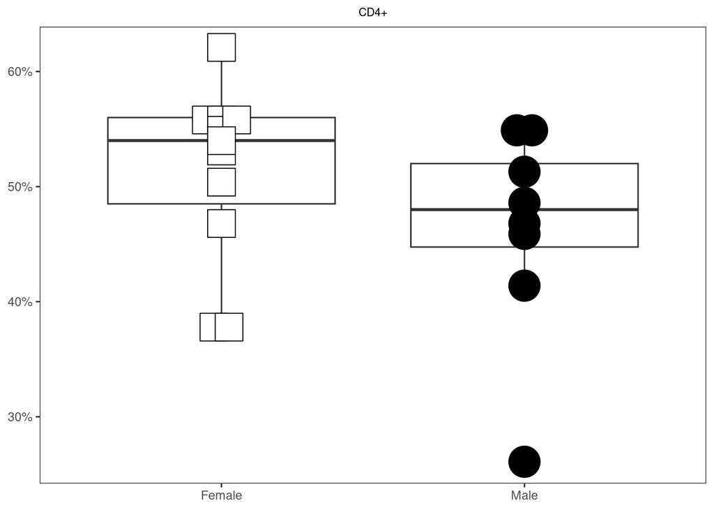

```r
StatPlotsForFlow_modified(data=Data, theColumn="CD4+", theFactor="infant_sex",
     shape_palette=shape_sex, fill_palette=fill_sex, percentages = TRUE,
     cex = 2.5, size = 10)
```

# Problem 3

> Some “typical” immunology workflows run a “normality” test before implementing a corresponding downstream test based on the result (Your friendly-neighbourhood statistician may have some strong thoughts on this field practice). Regardless of your position on this approach, see if you can modify our StatsFromFlow() function, using additional arguments conditional statements, to incorporate in a shapiro-wilks or fBasics package Omnibus K2 test first, and based on the outputs proceed downstream to either the parametric or non-parametric options

```r
#' Helper function that wraps the various statistical test to
#' enable quick statistical outputs for our extracted data
#'
#' A normality test is used for deciding whether to use parametric or non-parametric test.
#'
#' @param data The data.frame or tibble object containing our dataset
#' @param theColumn The column containing our measurements of interest
#' @param theFactor The column containing our metadata to compare by
#######' @param parametric Whether to use parametric or non-parametric test
#' @param test A character string either 'dagostino' or 'shapiro_wilk' gives the method
#' used to perform normality test.
#' @param alpha Default set to 0.05
#' @param correction Method for FDR correction, default is "none"
#' @param debug A logical value telling whether to print debug output
#'
StatsFromFlow_modified <- function(data, theColumn, theFactor,
#parametric,
     test = "dagostino",
     alpha=0.05, correction="none", debug = FALSE){

     myprint <- function(s) { if (debug) cat(s)}

     #theColumn <- x
     GateName <- theColumn
     FactorName <- theFactor

     FactorLevels <- data[[theFactor]] |> unique() |> length()

     if (test == "dagostino") {
          test_function <- fBasics::dagoTest  # D'Agostino-Pearson K² test
          myprint("Testing normality using D'Agostino's test\n")
     } else if (test == "shapiro_wilk") {
          test_function <- stats::shapiro.test
          myprint("Testing normality using Shapiro-Wilk's test\n")
     } else {
          stop("Unknow test:", test)
     }

     # Boolean variable telling whether all variables are normally distributed
     non_normal <- data %>%
          group_by(across(all_of(theFactor))) %>%
          # Both test functions return an object of class "htest"
          summarise(p_value = test_function(.data[[theColumn]]) %>% pluck("p.value")) %>%
          mutate(significant = p_value < alpha) %>%
          (\(x) if (debug) print(x) else x ) %>%
          pull(significant) %>%
          any()
     parametric <- if (non_normal) "non-parametric" else "parametric"
     sprintf("Performing %s test on variables %s with %i levels\n", parametric, theColumn, FactorLevels) %>% myprint()

     if (parametric=="parametric" && FactorLevels == 2){

          myprint("parametric with 2-levels\n")
          Results <- tidy(t.test(data[[theColumn]] ~ data[[theFactor]],
          alternative = "two.sided", var.equal = TRUE))

     } else if (parametric=="non-parametric" && FactorLevels == 2){

          myprint("non-parametric with 2-levels\n")
          Results <- tidy(wilcox.test(data[[theColumn]] ~ data[[theFactor]],
          alternative = "two.sided", exact=FALSE))

     } else if (parametric=="parametric" && FactorLevels == 3){
          myprint("parametric with 3-levels\n")
          Results <- tidy(aov(data[[theColumn]] ~ data[[theFactor]], data = data))
          Results <- Results[1,]
          Results <- Results |> mutate(method="One-Way Anova")

          if (!is.na(Results$p.value) && Results$p.value <= alpha){
               Pairwise <- tidy(pairwise.t.test(data[[theColumn]], data[[theFactor]],
                                   p.adjust.method = correction))
               Pairwise$method <- "Pairwise t-test"
               Results <- Pairwise
          }

     } else if (parametric=="non-parametric" && FactorLevels == 3){
          myprint("non-parametric with 3-levels\n")
          Results <- tidy(kruskal.test(data[[theColumn]] ~ data[[theFactor]], data = data))

          if (!is.na(Results$p.value) && Results$p.value <= alpha){
               Pairwise <- tidy(pairwise.wilcox.test(data[[theColumn]], g=data[[theFactor]],
               p.adjust.method = correction, exact=FALSE))
               Pairwise$method <- "Pairwise Wilcox test"
               Results <- Pairwise
          }

     } else (stop("Sorry, we didn't plan for your use case"))

     Results <- Results |> mutate(GateName=GateName) |> mutate(FactorName=FactorName)
     return(Results)
}
```

```r
colnames(Data)
```

```
 [1] "specimen"    "Condition"   "timepoint"   "ptype"       "infant_sex"
 [6] "singlets"    "lymphocytes" "Tcells"      "Tcells_CD27" "Vd2+"
[11] "Vd2_CD107a"  "Vd2_IL2"     "Vd2_TNFa"    "Vd2_IFNg"    "Vd2-"
[16] "CD4+"        "CD4_CD107a"  "CD4_IL2"     "CD4_TNFa"    "CD4_IFNg"
[21] "CD4-"        "CD8+"        "CD8_CD107a"  "CD8_IL2"     "CD8_TNFa"
[26] "CD8_IFNg"    "CD8-"        "DN_CD107a"   "DN_IL2"      "DN_TNFa"
[31] "DN_IFNg"     "Tcells_CCR7"
```

```r
Data %>% count(ptype)
```

| ptype | n |
| --- | --- |
| HEU-hi | 6 |
| HEU-lo | 6 |
| HU | 7 |

```r
TheseColumns <- colnames(Data)[6:9]               # 6:ncol(Data)
TheseColumns %>%
     purrr::map(\(column) StatsFromFlow_modified(
          data=Data, theColumn=column,
          #theFactor="ptype",
          theFactor = "infant_sex",
          test = "shapiro_wilk",    # too little data for D'Agostino's test
          alpha=0.05, debug = TRUE)
          ) %>%
     bind_rows()
```

```
Testing normality using Shapiro-Wilk's test
# A tibble: 2 × 3
  infant_sex p_value significant
  <chr>        <dbl> <lgl>
1 Female      0.0183 TRUE
2 Male        0.0370 TRUE
Performing non-parametric test on variables singlets with 2 levels
non-parametric with 2-levels
Testing normality using Shapiro-Wilk's test
# A tibble: 2 × 3
  infant_sex p_value significant
  <chr>        <dbl> <lgl>
1 Female       0.683 FALSE
2 Male         0.785 FALSE
Performing parametric test on variables lymphocytes with 2 levels
parametric with 2-levels
Testing normality using Shapiro-Wilk's test
# A tibble: 2 × 3
  infant_sex p_value significant
  <chr>        <dbl> <lgl>
1 Female     0.683   FALSE
2 Male       0.00424 TRUE
Performing non-parametric test on variables Tcells with 2 levels
non-parametric with 2-levels
Testing normality using Shapiro-Wilk's test
# A tibble: 2 × 3
  infant_sex p_value significant
  <chr>        <dbl> <lgl>
1 Female     0.497   FALSE
2 Male       0.00147 TRUE
Performing non-parametric test on variables Tcells_CD27 with 2 levels
non-parametric with 2-levels
```

| statistic | p.value | method | alternative | GateName | FactorName | estimate | estimate1 | estimate2 | parameter | conf.low | conf.high |
| --- | --- | --- | --- | --- | --- | --- | --- | --- | --- | --- | --- |
| 54.50000 | 0.3644471 | Wilcoxon rank sum test with continuity correction | two.sided | singlets | infant_sex | NA | NA | NA | NA | NA | NA |
| 1.36106 | 0.1912654 | Two Sample t-test | two.sided | lymphocytes | infant_sex | 0.0190909 | 0.7690909 | 0.75 | 17 | -0.0105024 | 0.0486842 |
| 64.00000 | 0.1053570 | Wilcoxon rank sum test with continuity correction | two.sided | Tcells | infant_sex | NA | NA | NA | NA | NA | NA |
| 57.00000 | 0.2959918 | Wilcoxon rank sum test with continuity correction | two.sided | Tcells_CD27 | infant_sex | NA | NA | NA | NA | NA | NA |